# Composition Analysis of the Short-Title Catalogue Netherlands dated 2025-10-24

# Overall summary

213,804 records and 15,436,187 attribute values in total. Constituent files:

- data/stcn/stcn.parquet (44.1MB)

## Temporal overview

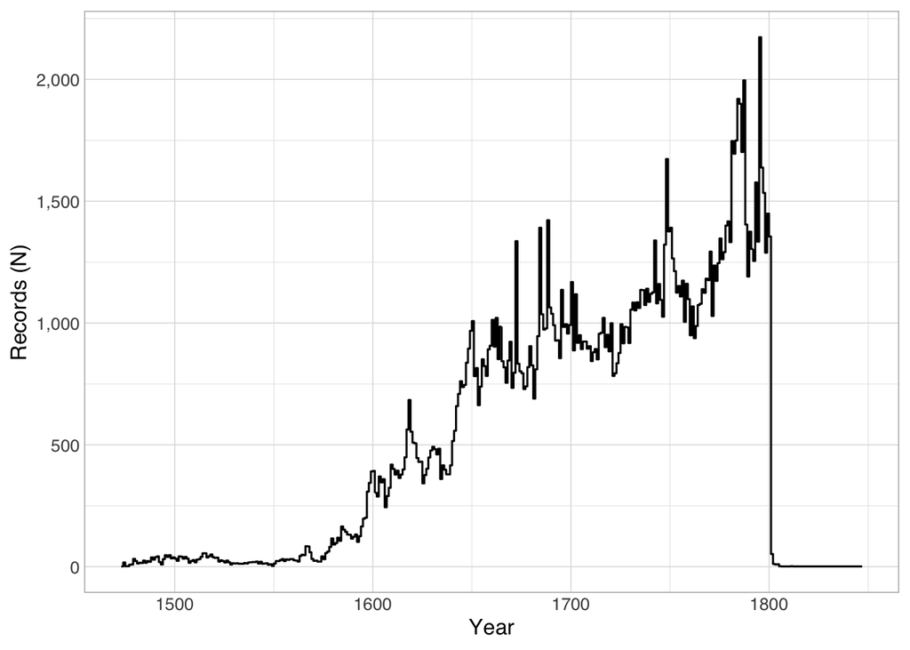

18,682 records do not have easily parseable dates between the years 1000 and 2050.

## Language overview

| [] | Records (N) | Proportion (%) |
| --- | --- | --- |
| ned | 141914 | 0.641799212188912 |
| lat (Latin) | 48789 | 0.22064589655344 |
| fra | 23420 | 0.105915819083842 |
| dui | 1341 | 0.0060646077451508 |
| eng (English) | 1273 | 0.00575708102876732 |
| heb (Hebrew) | 985 | 0.00445461493584902 |
| grk | 865 | 0.0039119207304664 |
| ita (Italian) | 557 | 0.00251900560331767 |
| mis (Uncoded languages) | 394 | 0.00178184597433961 |
| spa (Spanish; Castilian) | 324 | 0.00146527435453308 |

[output cut: 37 more lines]

# Field code usage overview

In total, 60 distinct fields are used.

Legend for the table below:

- `records`: how many records have at least one of this field
- `r_p`: the above as a percentage of all records
- `n`: the total number of appearances of this field
- `vals_per_rec`: calculated from the above, the mean number of appearances of this field per record
- `recs_with_mult_vals`: the number of records that have more than one repetition of this field

| field_code | field_description | records | r_p | n | vals_per_rec | recs_with_mult_vals |
| --- | --- | --- | --- | --- | --- | --- |
| <a name="001@" href="https://support.oclc.org/ggc/richtlijnen/?id=12&ln=nl&sec=k-0000">001@</a> | ILN-bits, supplier code a.o. | 213804 | 1 | 213804 | 1 | 0 |
| <a name="001A" href="https://support.oclc.org/ggc/richtlijnen/?id=12&ln=nl&sec=k-0200">001A</a> | Source and date of creation | 213804 | 1 | 213804 | 1 | 0 |
| <a name="001B" href="https://support.oclc.org/ggc/richtlijnen/?id=12&ln=nl&sec=k-0210">001B</a> | Source and date of the last transaction | 213804 | 1 | 427608 | 2 | 213804 |
| <a name="001D" href="https://support.oclc.org/ggc/richtlijnen/?id=12&ln=nl&sec=k-0230">001D</a> | Source and date of owner | 213804 | 1 | 213804 | 1 | 0 |
| <a name="001U" href="https://support.oclc.org/ggc/richtlijnen/?id=12&ln=nl&sec=k-000K">001U</a> | Characterset | 213804 | 1 | 213804 | 1 | 0 |
| <a name="001X" href="https://support.oclc.org/ggc/richtlijnen/?id=12&ln=nl&sec=k-000A">001X</a> | Owner main record | 213804 | 1 | 213805 | 1.00000467718097 | 1 |
| <a name="001Z" href="https://support.oclc.org/ggc/richtlijnen/?id=12&ln=nl&sec=k-5300">001Z</a> | GOO sourcecode | 4829 | 0.0225861069016482 | 4829 | 1 | 0 |
| <a name="002@" href="https://support.oclc.org/ggc/richtlijnen/?id=12&ln=nl&sec=k-0500">002@</a> | Bibliographic type and status | 213804 | 1 | 213804 | 1 | 0 |
| <a name="003@" href="https://support.oclc.org/ggc/richtlijnen/?id=12&ln=nl&sec=k-010X">003@</a> | Record Control Number (PPN) | 213804 | 1 | 213804 | 1 | 0 |
| <a name="007P" href="https://support.oclc.org/ggc/richtlijnen/?id=12&ln=nl&sec=k-2275">007P</a> | Fingerprint | 213165 | 0.997011281360498 | 566589 | 2.65798325241011 | 210964 |

[output cut: 50 more lines]

# Field code usage overview by subfield

In total, 137 distinct field+subfield combinations are used.

Legend for the table below:

- `records`: how many records have at least one of this field+subfield
- `r_p`: the above as a percentage of all records
- `dist_vals`: the number of different values appearing in this field+subfield
- `e_vals`: at most seven random sample values of this field+subfield
- `n`: the total number of appearances of this field+subfield
- `vals_per_rec`: calculated from the above, the mean number of appearances of this field+subfield per record
- `recs_with_mult_vals`: the number of records that have more than one repetition of this field+subfield

| subfield_code | subfield_description | records | r_p | dist_vals | e_vals | n | vals_per_rec | recs_with_mult_vals |
| --- | --- | --- | --- | --- | --- | --- | --- | --- |
| [001@: ILN-bits, supplier code a.o.](https://support.oclc.org/ggc/richtlijnen/?id=12&ln=nl&sec=k-0000) |  |  |  |  |  |  |  |  |
| 001@$0 | ILN-bits, userbits | 213,804 | 100% | 1 | 20 (213804) | 213,804 | 1 | 0 |
| [001A: Source and date of creation](https://support.oclc.org/ggc/richtlijnen/?id=12&ln=nl&sec=k-0200) |  |  |  |  |  |  |  |  |
| 001A$0 | Source and date | 213,804 | 100% | 7,978 | 1996:13-02-01 (9)\|1996:09-02-95 (25)\|1996:07-05-03 (16)\|1996:23-07-13 (30)\|1996:23-11-82 (12)\|1996:28-01-94 (15)\|1996:17-04-90 (20) | 213,804 | 1 | 0 |
| [001B: Source and date of the last transaction](https://support.oclc.org/ggc/richtlijnen/?id=12&ln=nl&sec=k-0210) |  |  |  |  |  |  |  |  |
| 001B$0 | Source and date | 213,804 | 100% | 234 | 1996:08-03-11 (4)\|1996:21-01-20 (6)\|1996:15-11-19 (6)\|1996:17-10-11 (1)\|1996:14-12-19 (1)\|1996:17-10-19 (20)\|1996:01-12-19 (2) | 213,804 | 1 | 0 |
| 001B$t | Timestamp | 213,804 | 100% | 22,776 | 21:30:39.000 (19)\|16:42:43.000 (1)\|16:52:01.000 (1)\|21:56:47.000 (9)\|16:31:44.000 (2)\|20:19:10.000 (14)\|18:58:58.000 (20) | 213,804 | 1 | 0 |
| [001D: Source and date of owner](https://support.oclc.org/ggc/richtlijnen/?id=12&ln=nl&sec=k-0230) |  |  |  |  |  |  |  |  |
| 001D$0 | Source and date | 213,804 | 100% | 7,647 | 1996:21-10-19 (30)\|1996:13-03-97 (36)\|1996:10-03-92 (16)\|1996:18-05-07 (23)\|1996:16-11-00 (103)\|1996:10-12-02 (106)\|1996:29-06-06 (61) | 213,804 | 1 | 0 |
| [001U: Characterset](https://support.oclc.org/ggc/richtlijnen/?id=12&ln=nl&sec=k-000K) |  |  |  |  |  |  |  |  |
| 001U$0 | NA | 213,804 | 100% | 1 | utf8 (213804) | 213,804 | 1 | 0 |
| [001X: Owner main record](https://support.oclc.org/ggc/richtlijnen/?id=12&ln=nl&sec=k-000A) |  |  |  |  |  |  |  |  |
| 001X$0 | Owner | 213,804 | 100% | 1 | 20 (213804) | 213,804 | 1 | 0 |
| 001X$B | ORS-flag | 1 | 0% | 1 | 96 (1) | 1 | 1 | 0 |
| [001Z: GOO sourcecode](https://support.oclc.org/ggc/richtlijnen/?id=12&ln=nl&sec=k-5300) |  |  |  |  |  |  |  |  |
| 001Z$0 | Sourcecode | 4,829 | 2.26% | 2 | 1996 (4828)\|1003 (1) | 4,829 | 1 | 0 |
| [002@: Bibliographic type and status](https://support.oclc.org/ggc/richtlijnen/?id=12&ln=nl&sec=k-0500) |  |  |  |  |  |  |  |  |
| 002@$0 | NA | 213,804 | 100% | 6 | Aar (2)\|Acv (583)\|Aav (206066)\|Abv (7125)\|Aax (26)\|Aac (2) | 213,804 | 1 | 0 |
| [003@: Record Control Number (PPN)](https://support.oclc.org/ggc/richtlijnen/?id=12&ln=nl&sec=k-010X) |  |  |  |  |  |  |  |  |
| 003@$0 | Number | 213,804 | 100% | 213,804 | 11188294X (1)\|111112699 (1)\|363309780 (1)\|840551509 (1)\|85317945X (1)\|183177088 (1)\|329482211 (1) | 213,804 | 1 | 0 |
| [007P: Fingerprint](https://support.oclc.org/ggc/richtlijnen/?id=12&ln=nl&sec=k-2275) |  |  |  |  |  |  |  |  |
| 007P$0 | Number | 213,165 | 99.7% | 2,722 | 214604 (1)\|175308 (288)\|037016 (1)\|179918 (1)\|161102 (19)\|039416 (1)\|044304 (1) | 234,645 | 1.1 | 13,051 |
| 007P$a | Part | 7,202 | 3.37% | 47 | 12 (72)\|18 (21)\| 13 (1)\|19 (15)\| 12 (1)\|16 (30)\|32 (1) | 22,304 | 3.1 | 7,202 |
| 007P$c | Fingerprint | 210,901 | 98.64% | 272,097 | a1 *2 $ap : a2 2*3 $exc (1)\|b1 A e : b2 C3 $V (1)\|b1 A2 au : b2 A3 fti (1)\|b1 A2 e,$ : *b2 2R2 wighe (1)\|b1 A2 $en : b2 B2 $ho (1)\|b1 A2 O.$ : b2 B3 ati (1)\|b1 A2 ere$ : b2 D3 lem (1) | 309,640 | 1.47 | 56,890 |
| [010@: Language designation](https://support.oclc.org/ggc/richtlijnen/?id=12&ln=nl&sec=k-1500) |  |  |  |  |  |  |  |  |
| 010@$a | Language of the publication | 213,804 | 100% | 47 | ara (97)\|esk (2)\|jid (148)\|ars (144)\|heb (985)\|chi (2)\|ndu (189) | 221,119 | 1.03 | 5,812 |
| 010@$b | Interlanguage | 911 | 0.43% | 12 | eng (93)\|fra (359)\|grk (6)\|ned (31)\|ara (3)\|heb (8)\|ita (20) | 941 | 1.03 | 28 |
| 010@$c | Language of the original | 26,715 | 12.5% | 45 | eng (6130)\|hon (2)\|ars (17)\|spa (893)\|dui (4548)\|per (3)\|egy (1) | 27,272 | 1.02 | 528 |
| [011@: PublicationDate](https://support.oclc.org/ggc/richtlijnen/?id=12&ln=nl&sec=k-1100) |  |  |  |  |  |  |  |  |
| 011@$a | Date of publication | 213,804 | 100% | 381 | 1591 (132)\|1635 (416)\|1582 (119)\|1505 (40)\|1608 (324)\|1491 (42)\|1683 (946) | 213,804 | 1 | 0 |

[output cut: 167 more lines]